# Assignment03

# 学生：王雅滢 (12132223)

# 得分：48/50

```python
import numpy as np
import pandas as pd
import matplotlib as mpl
import matplotlib.pyplot as plt
import matplotlib.gridspec as gridspec

%matplotlib inline

import netCDF4
import xarray as xr
```

```python
ds  = xr.open_dataset("NOAA_NCDC_ERSST_v3b_SST.nc", engine="netcdf4")
ds_re = ds.sel(lat=slice(-5,5),lon=slice(190,240))
#ds
```

```python
group_d = ds_re.sst.groupby('time.month')
monthly_mean = ds_re.sst.groupby('time.month').mean(dim='time')
anom = group_d - monthly_mean


print(anom.data)
```

[output not shown]

[output cut: 12 more lines]

[output not shown]

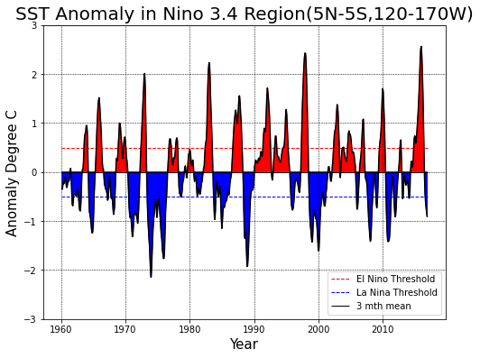

```python
anom_rol = anom.rolling(time=3,center=True).mean()

fig,ax = plt.subplots(1,1,figsize=[8,6])
line_anom =np.nanmean(anom_rol,axis=(1,2))
t = pd.date_range(start='1960-01',periods=684,freq='m')

ax.plot(t,line_anom,color='k')

ax.set_ylabel('Anomaly Degree C',color='k',fontsize=15)
ax.set_xlabel('Year',color='k',fontsize=15)
ax.set_title('SST Anomaly in Nino 3.4 Region(5N-5S,120-170W)',fontsize=20)

ax.grid(linestyle='--',linewidth=0.5,color='k')

ax.hlines(y=0.5,xmin=t[0],xmax=t[-1],color='r',ls='--',lw=1,label='EI Nino Threshold')
ax.hlines(y=-0.5,xmin=t[0],xmax=t[-1],color='b',ls='--',lw=1,label='La Nina Threshold')
ax.hlines(y=0,xmin=t[0],xmax=t[-1],color='k',ls='solid',lw=1,label='3 mth mean')

ax.set_ylim(-3,3)
ax.legend(loc=4,fontsize=10)

ax.fill_between(t,line_anom,where=(line_anom>0),color='r')
ax.fill_between(t,line_anom,where=(line_anom<0),color='b')
```

# 2. Earth’s energy budget

```python
import numpy as np
import xarray as xr
import matplotlib as mpl
import matplotlib.pyplot as plt
import matplotlib.gridspec as gridspec

# Show plots in the notebook
%matplotlib inline

import netCDF4
```

```python
ds  = xr.open_dataset("CERES_EBAF-TOA_200003-201701.nc", engine="netcdf4")
```

## 2.1 Make a 2D plot of the time-mean TOA longwave, shortwave, and solar radiation for all-sky conditions. Add up the three variables above and verify (visually) that they are equivalent to the TOA net flux.

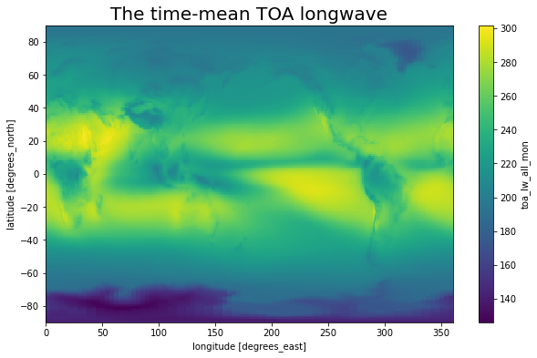

```python
ds.toa_lw_all_mon.mean(dim='time').plot(figsize=(10,6))
plt.title('The time-mean TOA longwave',fontsize = 20)
```

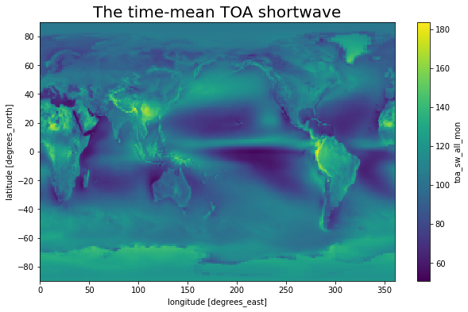

```python
ds.toa_sw_all_mon.mean(dim='time').plot(figsize=(10,6))
plt.title('The time-mean TOA shortwave',fontsize = 20)
```

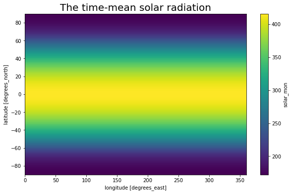

```python
ds.solar_mon.mean(dim='time').plot(figsize=(10,6))
plt.title('The time-mean solar radiation',fontsize = 20)
```

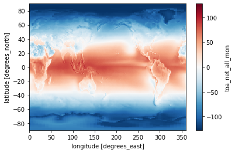

```python
ds.toa_net_all_mon.mean('time').plot()
```

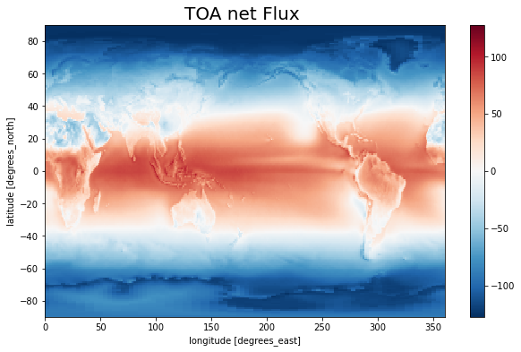

```python
net_flux = ds.solar_mon-ds.toa_lw_all_mon-ds.toa_sw_all_mon#和上面的图看起来是一样的
net_flux.mean(dim='time').plot(figsize=(10,6))
plt.title('TOA net Flux ',fontsize = 20)
```

## 2.2 Calculate and verify that the TOA incoming solar, outgoing longwave, and outgoing shortwave approximately match up with the cartoon above.

```python
weights = np.cos(np.deg2rad(ds.lat))

in_solar_weighted = ds.solar_mon.weighted(weights)
toa_lw_weighted = ds.toa_lw_all_mon.weighted(weights)
toa_sw_weighted = ds.toa_sw_all_mon.weighted(weights)

insolar=in_solar_weighted.mean(dim=('lon', 'lat','time')).values
lw=toa_lw_weighted.mean(dim=('lon', 'lat','time')).values
sw=toa_sw_weighted.mean(dim=('lon', 'lat','time')).values

print(insolar,lw,sw)
```

```
340.28326598091286 240.2669337478465 99.13805276923081
```

## 2.3 Calculate and plot the total amount of net radiation in each 1-degree latitude band. Label with correct units.

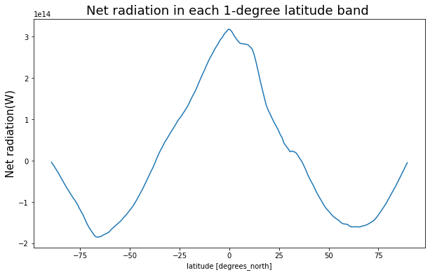

```python
#龚国庆、左小幸向我解释了此题
R=6371.4e3

equator_s = 2*np.pi**2*R**2/180
equator_s_weighted= equator_s * weights

nf = net_flux.mean(dim=('lon','time'))

total_amount = nf * equator_s_weighted
total_amount.plot(figsize=(10,6))
plt.title('Net radiation in each 1-degree latitude band ',fontsize = 18)
plt.ylabel('Net radiation(W)',fontsize = 15)
```

## 2.4 Calculate and plot composites of time-mean outgoing shortwave and longwave radiation for low and high cloud area regions. Here we define low cloud area as ≤25% and high cloud area as ≥75%. Your results should be 2D maps.

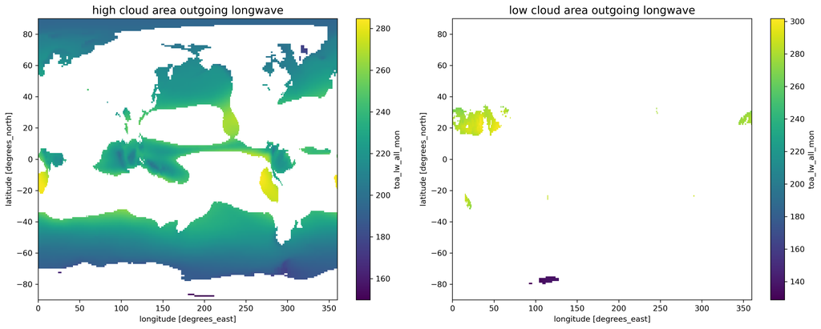

```python
fig,axes = plt.subplots(1,2,figsize=(15,6),dpi=300)
cloud_map = ds.cldarea_total_daynight_mon.mean(dim='time')
longwave_r = ds.toa_lw_all_mon.mean(dim='time')
longwave_r.where(cloud_map >= 75).plot(ax=axes[0])
longwave_r.where(cloud_map <= 25).plot(ax=axes[1])

axes[0].set_title('high cloud area outgoing longwave',fontsize = 14)
axes[1].set_title('low cloud area outgoing longwave',fontsize = 14)

plt.tight_layout()
```

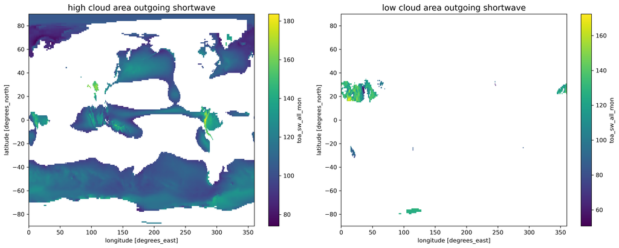

```python
fig,axes = plt.subplots(1,2,figsize=(15,6),dpi=300)

shortwave_r = ds.toa_sw_all_mon.mean(dim='time')

shortwave_r.where(cloud_map >= 75).plot(ax=axes[0])
shortwave_r.where(cloud_map <= 25).plot(ax=axes[1])

axes[0].set_title('high cloud area outgoing shortwave',fontsize = 14)
axes[1].set_title('low cloud area outgoing shortwave',fontsize = 14)

plt.tight_layout()
```

## 2.5 Calculate the global mean values of shortwave and longwave radiation, composited in high and low cloud regions. What is the overall effect of clouds on shortwave and longwave radiation?

```python
HL=longwave_r.where(cloud_map >= 75)
LL=longwave_r.where(cloud_map <= 25)
print('high cloud longwave:',np.nanmean(HL),'(W/m2)')
print('low cloud longwave:',np.nanmean(LL),'(W/m2)')

HS=shortwave_r.where(cloud_map >= 75)
LS=shortwave_r.where(cloud_map <= 25)
print('high cloud shortwave:',np.nanmean(HS),'(W/m2)')
print('low cloud shortwave:',np.nanmean(LS),'(W/m2)')
```

```
high cloud longwave: 216.55675 (W/m2)
low cloud longwave: 270.10367 (W/m2)
high cloud shortwave: 108.09777 (W/m2)
low cloud shortwave: 122.65546 (W/m2)
```

## 多云应增强长波 弱化短波，正确结果如下：

```
high_cloud_global_lw_mean = ds.toa_lw_all_mon.where(ds.cldarea_total_daynight_mon >= 75).mean(dim = 'time').mean(dim = ['lat','lon'])
low_cloud_global_lw_mean = ds.toa_lw_all_mon.where(ds.cldarea_total_daynight_mon <= 25).mean(dim = 'time').mean(dim = ['lat','lon'])
high_cloud_global_aw_mean = ds.toa_sw_all_mon.where(ds.cldarea_total_daynight_mon >= 75).mean(dim = 'time').mean(dim = ['lat','lon'])
low_cloud_global_aw_mean = ds.toa_sw_all_mon.where(ds.cldarea_total_daynight_mon <= 25).mean(dim = 'time').mean(dim = ['lat','lon'])


out:
high_cloud_global_lw_mean = 251.37349
low_cloud_global_lw_mean = 233.06702
high_cloud_global_sw_mean = 114.74328
low_cloud_global_sw_mean = 88.81645
```

## PS3-2.4.应先按照经纬度和时间判断云盖率，再把求出来的wave分布在时间上做平均，扣1分

```python
ds  = xr.open_dataset("air.sig995.2012.nc", engine="netcdf4")
```

```python
group_data = ds.air.groupby('time.month')
air_anom = group_data - group_data.mean(dim='time')
line_air_anom = air_anom.mean(dim=('lat','lon'))
```

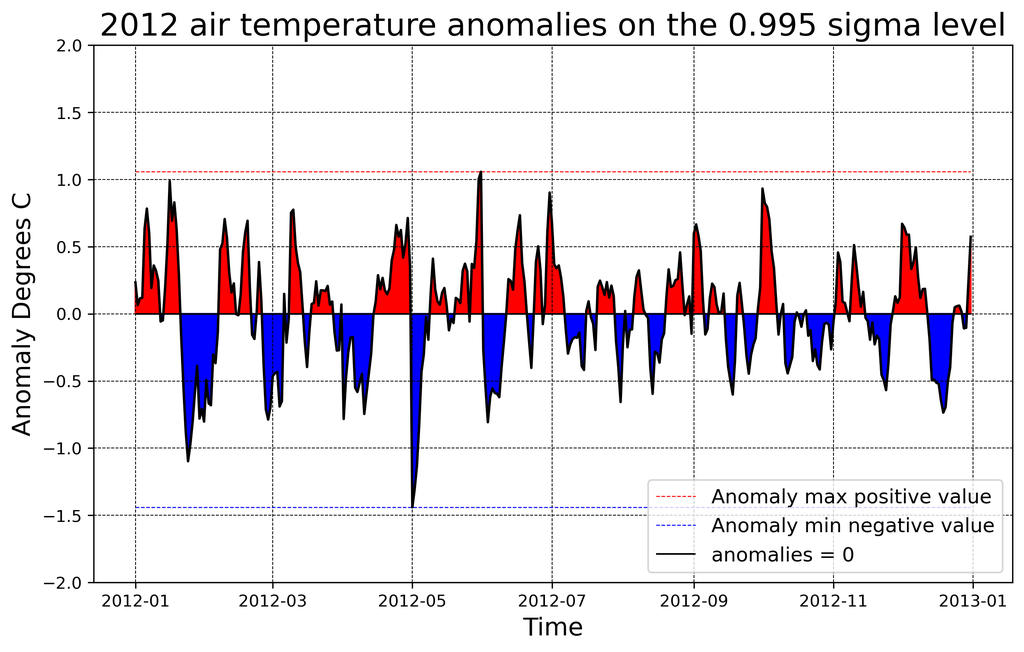

```python
time = pd.date_range(start='2012-01-01',periods=366,freq='d')
fig,ax = plt.subplots(1,1,figsize = [10,6],dpi=300)
ax.plot(time,line_air_anom,color='k')

ax.set_ylabel('Anomaly Degrees C', color='k', fontsize=15)
ax.set_xlabel('Time', color='k', fontsize=15)
ax.set_title("2012 air temperature anomalies on the 0.995 sigma level", fontsize=19)

ax.grid(linestyle='--',linewidth=0.5,color='k')

ax.hlines(y = line_air_anom.max(),xmin=time[0],xmax=time[-1],color='r',linestyles='--',lw=0.6,label='Anomaly max positive value')
ax.hlines(y = line_air_anom.min(),xmin=time[0],xmax=time[-1],color='b',linestyles='--',lw=0.6,label='Anomaly min negative value')
ax.hlines(y = 0,xmin=time[0],xmax=time[-1],color='k',linestyles='solid',lw=1,label='anomalies = 0')

ax.set_ylim(-2,2)
ax.legend(loc=4,fontsize=12)


ax.fill_between(time,0,line_air_anom,where=(line_air_anom>0),color='r')
ax.fill_between(time,0,line_air_anom,where=(line_air_anom<0),color='b')
```

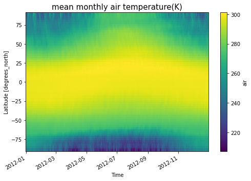

```python
#1 不同纬度全球月平均空气温度
mean_monthly = ds.air.groupby('time.month').mean(dim=('lon'))
mean_monthly.plot(x='time',figsize=(8,5))
plt.title('mean monthly air temperature(K)',fontsize=15)
```

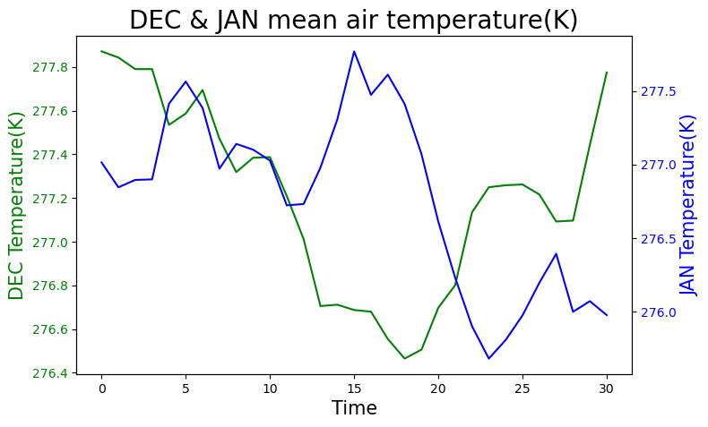

```python
#2&3 全球十二月份和一月份的平均空气温度

fig, ax1 = plt.subplots(1,1,figsize=(8,5), dpi=100)
ax1.plot(ds.air.sel(time=slice('2012-12-01', '2012-12-31')).mean(dim=('lon','lat')), color='g')

ax2 = ax1.twinx()
ax2.plot(ds.air.sel(time=slice('2012-01-01', '2012-01-31')).mean(dim=('lon','lat')), color='b')

ax1.set_xlabel('Time', color='k', fontsize=15)
ax1.set_ylabel('DEC Temperature(K)', color='g', fontsize=15)
ax2.set_ylabel('JAN Temperature(K)', color='b', fontsize=15)


ax1.tick_params(axis='y', rotation=0, labelcolor='g')
ax2.tick_params(axis='y', rotation=0, labelcolor='b')
ax2.set_title("DEC & JAN mean air temperature(K)", fontsize=20)
```

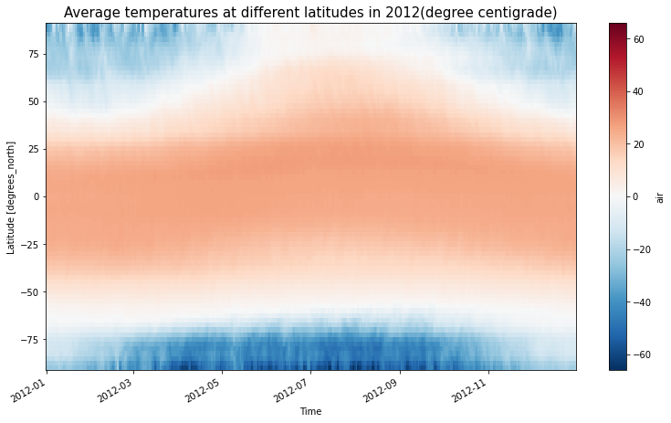

```python
#4 2012年不同纬度的平均温度
C_temperture= ds.air - 273.15
C_temperture.mean(dim=('lon')).plot(x='time',figsize=(13,7))
plt.title('Average temperatures at different latitudes in 2012(degree centigrade)',fontsize=15)
```

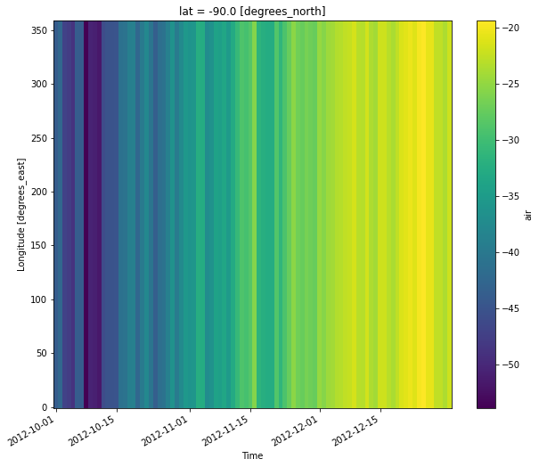

```python
#5 Lat=90S时，10-12月的平均气温
da_air_Ant = ds.air.sel(lat='-90',time=slice('2012-10-01','2012-12-31'))-273.15
da_air_Ant.plot(x='time',figsize=(10,8))
```